# Foundations for statistical inference - Confidence intervals

If you have access to data on an entire population, say the opinion of every adult in the United States on whether or not they think climate change is affecting their local community, it’s straightforward to answer questions like, “What percent of US adults think climate change is affecting their local community?”. Similarly, if you had demographic information on the population you could examine how, if at all, this opinion varies among young and old adults and adults with different leanings. If you have access to only a sample of the population, as is often the case, the task becomes more complicated. What is your best guess for this proportion if you only have data from a small sample of adults? This type of situation requires that you use your sample to make inference on what your population looks like.

## Getting Started

### The data

A 2019 Pew Research report states the following:

To keep our computation simple, we will assume a total population size of 100,000 (even though that’s smaller than the population size of all US adults).

> Roughly six-in-ten U.S. adults (62%) say climate change is currently affecting their local community either a great deal or some, according to a new Pew Research Center survey.

> **Source:** [Most Americans say climate change impacts their community, but effects vary by region](https://www.pewresearch.org/fact-tank/2019/12/02/most-americans-say-climate-change-impacts-their-community-but-effects-vary-by-region/)

In this lab, you will assume this 62% is a true population proportion and learn about how sample proportions can vary from sample to sample by taking smaller samples from the population.

First, open Rguroo’s data editor by selecting **Create New Dataset** in the **Data** section. In the data editor, create the variable *Affects* with two values of “yes” and “no.” To add variables click `Add Column` and to add rows click *Add Row* . Next, add a “Probability” column to the dataset, which provides a vector of the two probability weights. Here, since we assume 62% of responses will be from people who think climate change impacts their community, the probability of “yes” should be 0.62 and the probability of “no” should be 0.38, as shown in the figure below. **Save** the dataset with the name *climate_change_affects*.

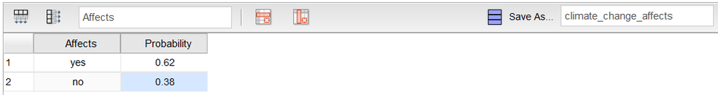

We can quickly visualize the distribution of these responses using a bar plot.

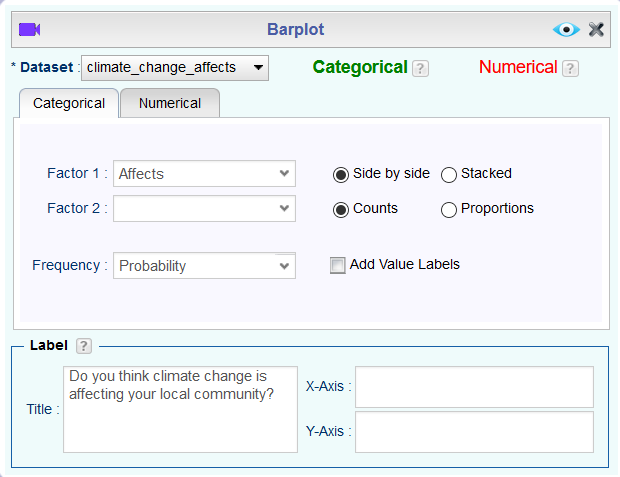

In this lab, you’ll start with a simple random sample of size 60 from the population. Remember that we use the **Random Selection** dialog in the **Probability-Simulation** section to take random samples from our dataset. Again, change the `Seed` from 100 to a different number of your choice. In this example, we have arbitrarily chosen the number 32055.

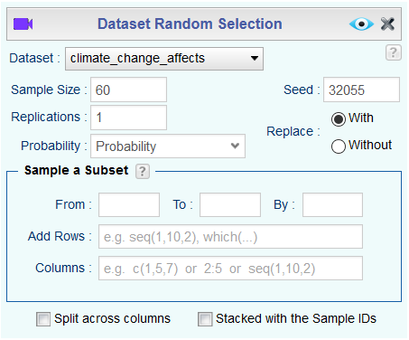

**Save** the dataset as *climate_change_sample*.

1. What percent of the adults in your sample think climate change affects their local community? **Hint:** Use the **Dataset Summary** to find the number of “yes” and “no” outcomes in the sample.
2. Would you expect another student’s sample proportion to be identical to yours? Would you expect it to be similar? Why or why not?

## Confidence intervals

Return for a moment to the question that first motivated this lab: based on this sample, what can you infer about the population? With just one sample, the best estimate of the proportion of US adults who think climate change affects their local community would be the sample proportion, usually denoted as $\hat{p}$ (here we are calling it `p_hat`). That serves as a good **point estimate**, but it would be useful to also communicate how uncertain you are of that estimate. This uncertainty can be quantified using a **confidence interval**.

One way of calculating a confidence interval for a population proportion is based on the Central Limit Theorem, as $\hat{p} \pm z^\star SE_{\hat{p}}$ is, or more precisely, as
$$\hat{p} \pm z^\star \sqrt{ \frac{\hat{p} (1-\hat{p})}{n} }$$

Another way is using simulation, or to be more specific, using **bootstrapping**. The term **bootstrapping** comes from the phrase “pulling oneself up by one’s bootstraps”, which is a metaphor for accomplishing an impossible task without any outside help. In this case the impossible task is estimating a population parameter (the unknown population proportion), and we’ll accomplish it using data from only the given sample. Note that this notion of saying something about a population parameter using only information from an observed sample is the crux of statistical inference, it is not limited to bootstrapping.

In essence, bootstrapping assumes that there are more of observations in the populations like the ones in the observed sample. So we “reconstruct” the population by resampling from our sample, with replacement. The bootstrapping scheme is as follows:

- **Step 1.** Take a bootstrap sample - a random sample taken **with replacement** from the original sample, of the same size as the original sample.
- **Step 2.** Calculate the bootstrap statistic - a statistic such as mean, median, proportion, slope, etc. computed on the bootstrap samples.
- **Step 3.** Repeat steps (1) and (2) many times to create a bootstrap distribution - a distribution of bootstrap statistics.
- **Step 4.** Calculate the bounds of the XX% confidence interval as the middle XX% of the bootstrap distribution.

Let’s think about how to do this in Rguroo.

- **Step 1.** Use **Random Selection** module to take a bootstrap sample from your *climate_change_sample* `Dataset`. Again, change the seed to the same seed you used earlier. Note that we do **not** put anything in the `Probability` menu because we want all 60 adults in our sample to be equally likely to be picked.

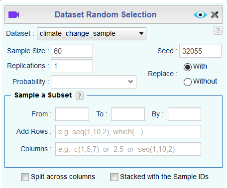

- **Step 2.** Click the button and create the bootstrap statistic we want. In this case we want to compute $\hat{p}$, the proportion of adults in the bootstrap sample who believe that climate change affects their community.

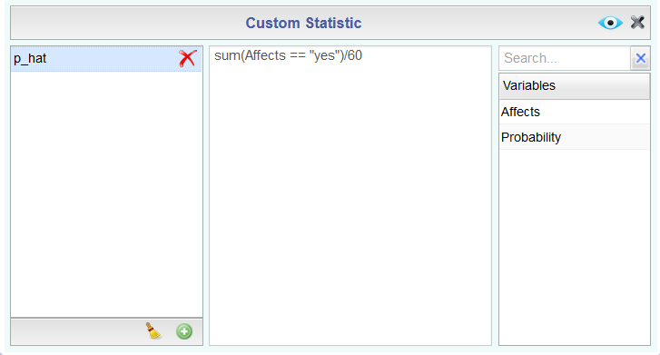

- **Step 3.** Go back to the **Dataset Random Selection** dialog and indicate the number of bootstrap samples we want as the number of `Replications`. In this example we want 1000 replications.

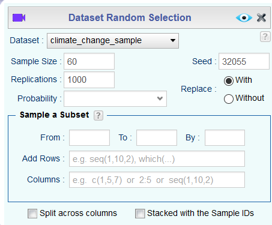

- **Step 4.** `Preview` the output. **Save** the process as *bootstrap_proportion* (you will want to use these steps later and it will be nice to have a template). Save the resulting dataset as *climate_change_bootstrap* and use the **Transform** function to calculate the bounds of the confidence interval.

We will create two variables, *CI_low* and *CI_high*, to represent the lower and upper bounds of the confidence interval. To get the middle 95% we need to look at the 2.5% and 97.5% quantiles, so in the center box we should type `quantile(p_hat, 0.025)` for *CI_low* and `quantile(p_hat, 0.975)` for *CI_high*. Finally, we check the `Complete Cases Only` box so that we only get 1 value for *CI_low* and 1 value for *CI_high* out.

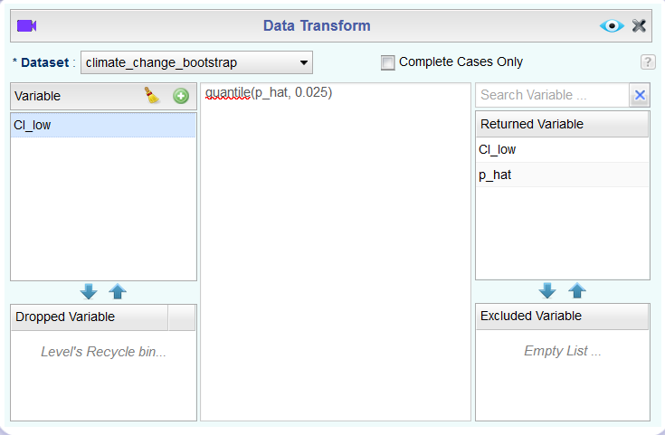

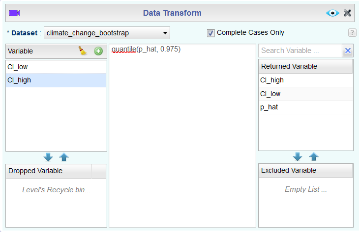

Finally, for the best-looking output results, move the *p_hat* variable to the `Excluded Variable` section and reorder the `Returned Variable` section so that *CI_low* is on the top of the list, as shown below. Finally, `Preview` the output and you should see the lower and upper bounds of the 95% confidence interval.

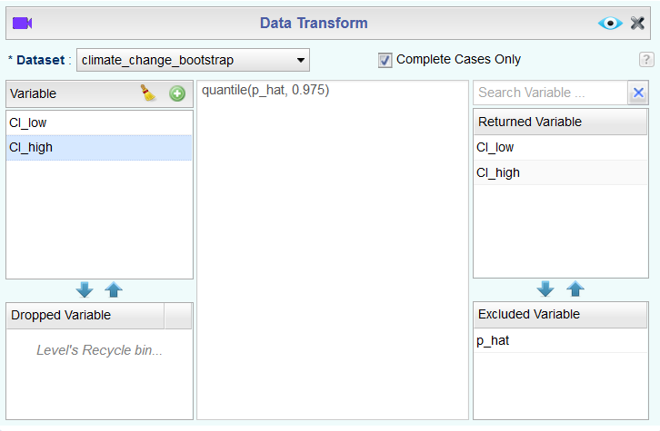

To recap: even though we don’t know what the full population looks like, we’re 95% confident that the true proportion of US adults who think climate change affects their local community is between the two bounds reported as result of this set of actions.

## Confidence levels

1. In the interpretation above, we used the phrase “95% confident”. What does “95% confidence” mean?

In this case, you have the rare luxury of knowing the true population proportion (62%) since you have data on the entire population.

1. Does your confidence interval capture the true population proportion of US adults who think climate change affects their local community? If you are working on this lab in a classroom, does your neighbor’s interval capture this value?
2. Each student should have gotten a slightly different confidence interval. What proportion of those intervals would you expect to capture the true population mean? Why?

## Confidence Intervals Using Central Limit Theorem

In the next part of the lab, you will collect many samples to learn more about how sample proportions and confidence intervals constructed based on those samples vary from one sample to another.

- Obtain a random sample.
- Calculate the sample proportion, and use this sample proportion to calculate and store the lower and upper bounds of the confidence intervals.
- Repeat these steps 1000 times.

We already did these steps in our *bootstrap_proportion* simulation, except we used a single random sample of size 60 as our population instead of the actual *climate_change_affects* dataset. So let’s open up the *bootstrap_proportion* simulation and change the `Dataset` to *climate_change_affects*. Remember to add the `Probability` variable so that you simulate with the proper probabilities of “yes” and “no”!

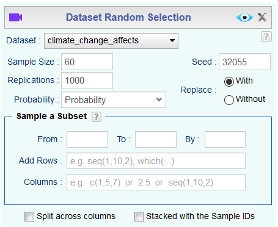

`Preview` the output and **Save** the resulting dataset as *climate_change_1000_samples*.

Now we can actually build the 1000 confidence intervals in Rguroo using the **Transform** function.

- **Step 1.** Compute the standard error of the sample proportion.
- **Step 2.** Use the result from step (1) to compute the margin of error.
- **Step 3.** Use the result from step (2) to compute the lower and upper bounds of the confidence interval.
- **Step 4.** Determine whether the confidence interval contains the true population proportion $p = 0.62$.

Let’s follow these steps in **Transform** function.

- **Step 1**. Create a new variable, *se*, and in the center box type `sqrt(p_hat * (1-p_hat)/60)`. This will give us the standard error for each of the 1000 sample proportions in the dataset. Note that we use *60* because that is the sample size for each of the 1000 sample proportions.

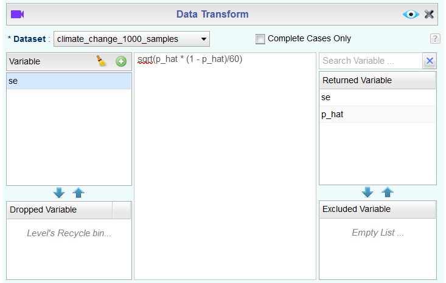

- **Step 2**. Create a new variable, *me*, and in the center box type `qnorm(0.975) * se`. The R function `qnorm` finds the $z^\star$ value for a confidence interval, We use 0.975 for a two-sided 95 percent confidence interval since the upper bound is at the 97.5% quantile.

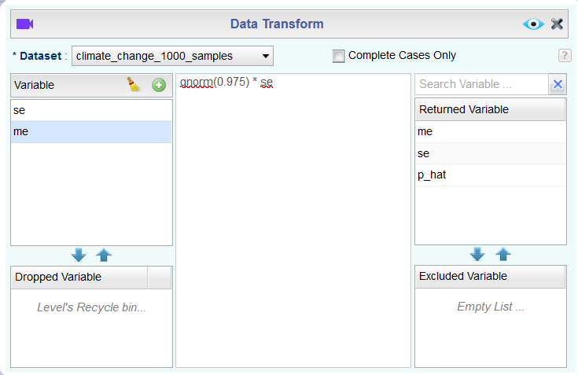

- **Step 3**. Create two new variables, *lower* and *upper*. For *lower* we should type in the center box `p_hat - me` to get the lower bound of the interval and for *upper* we should type in the center box `p_hat + me` to get the upper bound.

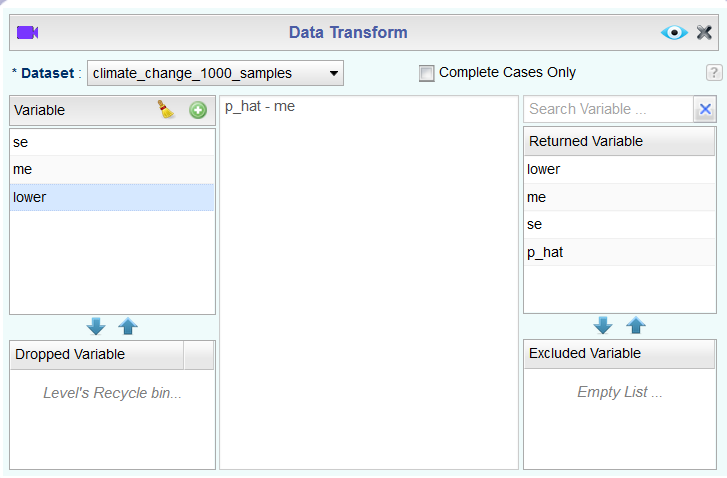

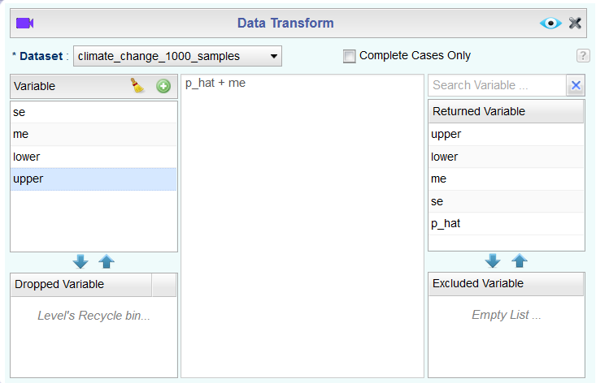

- **Step 4**. Create a new variable, *capture_p*, that will take the value *yes* if the true value of $p = 0.62$ has been “captured” by the interval and *no* if the true value of $p = 0.62$ is not in the interval. The center box code for this is `ifelse(lower < 0.62 & upper > 0.62, "yes", "no)`. Recall that the `ifelse` statement takes three arguments: first is a logical statement, second is the value we want if the logical statement yields a true result, and third is the value we want if the logical statement yields a false result.

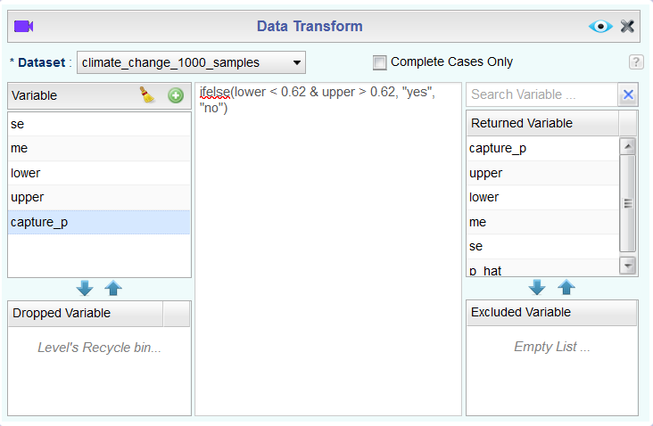

Finally, we will add one more variable, *prop_capture*, that will contain the proportion of intervals that contain the true value of $p = 0.62$. The center box code for this is `sum(capture_p == "yes")/1000`. Note that we are only returning one value for this variable, so the other 999 rows will be *NA*.

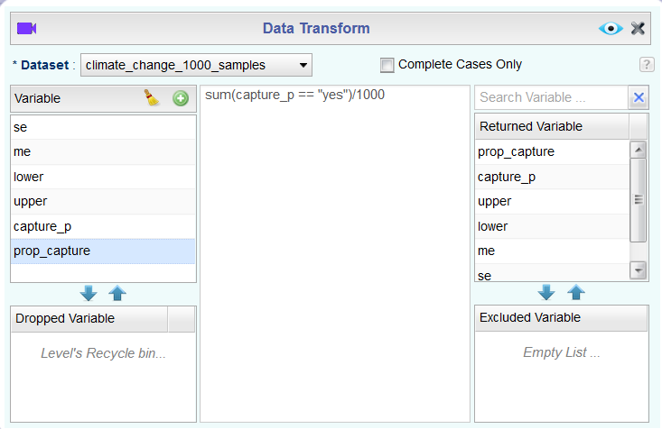

`Preview` the output and **Save** the resulting dataset as *climate_change_1000_CIs*.

1. What proportion of your 1000 confidence intervals include the true population proportion? Is this proportion exactly equal to the confidence level? If not, explain why.

## More Practice

1. Choose a different confidence level than 95%. Would you expect a confidence interval at this level to be wider or narrower than the confidence interval you calculated at the 95% confidence level? Explain your reasoning.
2. Using your *climate_change_bootstrap* dataset and the **Transform** function, find a confidence interval for the proportion of US Adults who think climate change is affecting their local community with a confidence level of your choosing (other than 95%) and interpret it. (**Hint:** you will have to figure out the appropriate numbers to use in `quantile`)
3. Reopen your *climate_change_1000_CIs* dataset, click , and modify the center box code for *me* to obtain 1000 confidence intervals at the confidence level you chose in the previous question and calculate the proportion of intervals that include the true population proportion. How does this percentage compare to the confidence level selected for the intervals?
4. Lastly, try one more (different) confidence level. First, state how you expect the width of this interval to compare to previous ones you calculated. Then, use the *climate_change_bootstrap* dataset to calculate the bounds of the interval and interpret it. Finally, use the *climate_change_1000_CIs* dataset to generate 1000 intervals using Central Limit Theorem and calculate the proportion of intervals that capture the true population proportion.
5. Given a sample size (say, 60), how does the width of the interval change as you increase the number of bootstrap samples? **Hint:** Open your *bootstrap_proportion* simulation, increase the number of `Replications`, save the new dataset, and look at the **Dataset Summary** for the old (*climate_change_bootstrap*) and new datasets. Does changing the number of bootstrap samples affect the calculated standard deviation of *p_hat*?

This work is licensed under a [Creative Commons Attribution-ShareAlike 4.0 International License](http://creativecommons.org/licenses/by-sa/4.0/).